# Enteropathogen seroepidemiology among children in low-resource settings

Rates of seroconversion and seroreversion in Asembo, Kenya, Figure 5

# Notebook Summary

This script estimates prospective seroincidence rates and the incidence proportion (cumulative incidence) over a 6-7 month period of seroconversion and seroreversion.

The Asembo study was longitudinal and followed children prospectively. We can estimate the average seroconversion rate among children who were at risk (seronegative) at enrollment and seroconverted during the study. We can also estimate the sero-reversion rate, albeit with much less precision since very few children were at risk (seropositive) at enrollment.

# Script preamble

```r
#-----------------------------
# preamble
#-----------------------------
library(here)
here()
```

```
## [1] "/Users/benarnold/enterics-seroepi"
```

```r
# load packages
library(tidyverse)
library(viridis)
library(gridExtra)
# set up for parallel computing
# configure for a laptop (use only 3 cores)
library(foreach)
library(doParallel)
```

```r
registerDoParallel(cores=3)

# bright color blind palette:  https://personal.sron.nl/~pault/
cblack <- "#000004FF"
cblue <- "#3366AA"
cteal <- "#11AA99"
cgreen <- "#66AA55"
cchartr <- "#CCCC55"
cmagent <- "#992288"
cred <- "#EE3333"
corange <- "#EEA722"
cyellow <- "#FFEE33"
cgrey <- "#777777"
```

```r
#-----------------------------
# load the formatted data
# created with
# asembo-enteric-ab-data-format.Rmd -->
# Fig1sup3-asembo-ab-distributions.Rmd
#-----------------------------
dl <- readRDS(here("data","asembo_analysis2.rds"))
```

# Identify incident changes

Identify children whose status changed between enrollment and follow-up. Those who changed from negative to positive are seroconverters (`seroi` below), and those who changed from positive to negative are seroreverters (`seror` below).

```r
#-----------------------------
# identify incident
# seroconversions and reversions
# based on a change in seropositivity
# status and
# based on a 4-fold change in MFI
# to above the cutoff (seroconversion)
# or starting above cutoff (seroreversion)
#-----------------------------
dlp <- dl %>%
  group_by(antigen,antigenf,childid) %>%
  mutate(measA=ifelse(time=="A",1,0),
         measA=max(measA),
         measB=ifelse(time=="B",1,0),
         measB=max(measB),
         seroposA=ifelse(time=="A",seropos,NA),
         seroposA=max(seroposA,na.rm=TRUE),
         seroposB=ifelse(time=="B",seropos,NA),
         seroposB=max(seroposB,na.rm=TRUE),
         seroi=ifelse(seroposB==1 & seroposA==0,1,0),
         seror=ifelse(seroposB==0 & seroposA==1,1,0),

         mfiA=ifelse(time=="A",logmfi,NA),
         mfiA=max(mfiA,na.rm=TRUE),
         mfiB=ifelse(time=="B",logmfi,NA),
         mfiB=max(mfiB,na.rm=TRUE),
         seroi4fold=ifelse(logmfidiff>log10(4) & mfiB>serocut,1,0),
         seror4fold=ifelse(logmfidiff< - log10(4) & mfiA>serocut,1,0)
  )



#-----------------------------
# drop 41 children that were not
# measured at both time points
#-----------------------------
table(dlp$antigen,(dlp$measA==1 & dlp$measB==1))
```

```
##
##           FALSE TRUE
##   cholera    41  398
##   cp17       41  398
##   cp23       41  398
##   etec       41  398
##   leca       41  398
##   p18        41  398
##   p39        41  398
##   salb       41  398
##   sald       41  398
##   vsp3       41  398
##   vsp5       41  398
```

```r
dlp <- dlp %>% filter(measA==1 & measB==1) %>%
  select(-measA,-measB)
```

# Seroincidence rate estimates

Estimates of the mean seroincidence rates during the study. The rates assume that incident sero-conversions and sero-reversions happened at the mid-point between measurements for each child.

As with the age-prevalence curve analysis, use information across multiple recombinant antigens for each pathogen when identifying risk periods and incident seroconversions and seroreversions.

Incident seroconversions are often used as a measure of a pathogen’s force of infection.

```r
#-----------------------------
# create composite
# seroincidence indicators
# that use information from
# multiple antigens for the
# same pathogen
#-----------------------------

dlp2 <- dlp %>%
  ungroup() %>%
  group_by(pathogen,childid) %>%
  mutate(seroi=max(seroi),
         seror=max(seror),
         seroi4fold=max(seroi4fold),
         seror4fold=max(seror4fold)
  ) %>%
  group_by(pathogen,childid,time) %>%
  slice(1) %>%
  mutate(antigenf=factor(antigenf,
                         levels=c("Giardia VSP-3 or VSP-5",
                                  "Cryptosporidium Cp17 or Cp23",
                                   "E. histolytica LecA",
                                  "Salmonella LPS groups B or D",
                                  "ETEC LT β subunit",
                                  "Cholera toxin β subunit",
                                  "Campylobacter p18 or p39"))
         )

dlp2$antigen[dlp2$pathogen=="Giardia"] <- "vsp3vsp5"
dlp2$antigen[dlp2$pathogen=="Cryptosporidium"] <- "cp17cp23"
dlp2$antigen[dlp2$pathogen=="Salmonella"] <- "salbsald"
dlp2$antigen[dlp2$pathogen=="Campylobacter"] <- "p18p39"

dlp2$antigenf[dlp2$pathogen=="Giardia"] <- "Giardia VSP-3 or VSP-5"
dlp2$antigenf[dlp2$pathogen=="Cryptosporidium"] <- "Cryptosporidium Cp17 or Cp23"
dlp2$antigenf[dlp2$pathogen=="Salmonella"] <- "Salmonella LPS groups B or D"
dlp2$antigenf[dlp2$pathogen=="Campylobacter"] <- "Campylobacter p18 or p39"

dlp2 <- dlp2 %>%
  filter(!is.na(antigenf)) %>%
  select(pathogen,antigen,antigenf,
         childid,time,tr,sex,age,agediff,
         roccut,mixcut,unexp,unexpcut,serocut,serocut_desc,
         posroc,posmix,posunex,seropos,seroi,seror,seroi4fold,seror4fold) %>%
  arrange(pathogen,antigenf,childid,time)
```

## Estimate prospective incidence rates based on seropositivity

```r
#-----------------------------
# estimate sero-incidence rates
# for conversion and reversion
# estimate SEs with a bootstrap
#-----------------------------
#-----------------------------
# filter to just 1 obs per child
# (enrolment information)
#-----------------------------
dp <- dlp2 %>% filter(time=="A")

#-----------------------------
# estimate time at risk
# for seroconversion and reversion
# assumed to be 1/2 of time
# between measurements
# if indivs are seropositive
# at measurement 1 they are
# not at risk for seroconversion
# (and vice-versa for seroreversion)
#-----------------------------
dp <- dp %>%
  mutate(ptc = ifelse(seropos==0,agediff,0),
         ptc = ifelse(seropos==0 & seroi==1,agediff/2,ptc),
         ptr = ifelse(seropos==1,agediff,0),
         ptr = ifelse(seropos==1 & seror==1,agediff/2,ptr))

#-----------------------------
# estimate incidence rates
# for each antibody
# units are episodes per child-year
# (dividing person time in months by 12)
#-----------------------------
rate_ests <- dp %>%
  group_by(antigenf) %>%
  summarize(ni=sum(seroi,na.rm=T),
            nit=sum(ptc,na.rm=T)/12,
            nr=sum(seror,na.rm=T),
            nrt=sum(ptr,na.rm=T)/12) %>%
  mutate(seroi=ni/nit,
         seror=nr/nrt)

#-----------------------------
# get bootstrap CIs
#-----------------------------
dboot <- dp %>%
  group_by(pathogen,antigen,antigenf) %>%
  select(pathogen,antigen,antigenf,seroi,seror,ptc,ptr)

set.seed(123)
bootests <- foreach(brep=1:1000,.combine=rbind) %dopar% {
    di <- sample_frac(dboot,size=1,replace=TRUE) %>%
      summarize_all(function(x) sum(x,na.rm=TRUE))
    }

rate_cis <- bootests %>%
  group_by(pathogen,antigen,antigenf) %>%
  mutate(sero_c=seroi/(ptc/12),sero_r=seror/(ptr/12)) %>%
  summarize(seroi_lb = quantile(sero_c,probs=c(0.025)),
            seroi_ub = quantile(sero_c,probs=c(0.975)),
            seror_lb = quantile(sero_r,probs=c(0.025),na.rm=T),
            seror_ub = quantile(sero_r,probs=c(0.975),na.rm=T)
            )

rate_ests <- left_join(rate_ests,rate_cis,by="antigenf") %>%
  select(pathogen,antigen,antigenf,ni,nit,starts_with("seroi"),nr,nrt,starts_with("seror"))
```

### Table of results

```r
rate_ests %>%
  select(antigenf,nit,ni,starts_with("seroi")) %>%
  knitr::kable(digits=1,
             caption="Incidence rates seroconversion per child year (force of infection)",
             col.names = c("Antigen","Years at risk","n events","Incidence per year","min95","max95"),
             row.names = FALSE)
```

Incidence rates seroconversion per child year (force of infection)

| Antigen | Years at risk | n events | Incidence per year | min95 | max95 |
| --- | --- | --- | --- | --- | --- |
| Giardia VSP-3 or VSP-5 | 82.8 | 59 | 0.7 | 0.5 | 0.9 |
| Cryptosporidium Cp17 or Cp23 | 69.8 | 89 | 1.3 | 1.0 | 1.5 |
| E. histolytica LecA | 101.2 | 11 | 0.1 | 0.0 | 0.2 |
| Salmonella LPS groups B or D | 94.1 | 25 | 0.3 | 0.2 | 0.4 |
| ETEC LT β subunit | 12.3 | 40 | 3.3 | 2.7 | 3.8 |
| Cholera toxin β subunit | 16.5 | 46 | 2.8 | 2.3 | 3.3 |
| Campylobacter p18 or p39 | 8.6 | 48 | 5.6 | 4.3 | 7.5 |

```r
rate_ests %>%
  select(antigenf,nrt,nr,starts_with("seror")) %>%
  knitr::kable(digits=1,
             caption="Incidence rates seroreversion per child year",
             col.names = c("Antigen","Years at risk","n events","Incidence per year","min95","max95"),
             row.names = FALSE)
```

Incidence rates seroreversion per child year

| Antigen | Years at risk | n events | Incidence per year | min95 | max95 |
| --- | --- | --- | --- | --- | --- |
| Giardia VSP-3 or VSP-5 | 8.5 | 3 | 0.4 | 0.0 | 0.9 |
| Cryptosporidium Cp17 or Cp23 | 13.9 | 17 | 1.2 | 0.7 | 2.1 |
| E. histolytica LecA | 2.9 | 3 | 1.0 | 0.0 | 2.7 |
| Salmonella LPS groups B or D | 5.0 | 8 | 1.6 | 0.7 | 2.8 |
| ETEC LT β subunit | 85.0 | 0 | 0.0 | 0.0 | 0.0 |
| Cholera toxin β subunit | 78.5 | 2 | 0.0 | 0.0 | 0.1 |
| Campylobacter p18 or p39 | 91.8 | 0 | 0.0 | 0.0 | 0.0 |

## Estimate prospective incidence rates based on 4-fold IgG increase

```r
#-----------------------------
# estimate sero-incidence rates
# for conversion and reversion
# estimate SEs with a bootstrap
#-----------------------------
#-----------------------------
# filter to just 1 obs per child
# (enrolment information)
#-----------------------------
dp <- dlp2 %>% filter(time=="A")

#-----------------------------
# estimate time at risk
# for seroconversion and reversion
# assumed to be 1/2 of time
# between measurements
# if indivs are seropositive
# at measurement 1 they are
# not at risk for seroconversion
# (and vice-versa for seroreversion)
# the exception are individuals
# who had a 4-fold increase in
# IgG who were above the cutoff
# This is admittedly a gray zone,
# but this harmonizes it with
# the definition used in the
# repeated measures analysis in
# the Haiti cohort. If this change
# were not made, then this definition
# would be identical to the definition
# used simply based on crossing
# the seroposivity cutoff
#-----------------------------
dp <- dp %>%
  mutate(ptc = ifelse(seropos==0,agediff,0),
         # ptc = ifelse(seropos==0 & seroi4fold==1,agediff/2,ptc), # not adding converters
         ptc = ifelse(seroi4fold==1,agediff/2,ptc),
         ptr = ifelse(seropos==1,agediff,0),
         # ptr = ifelse(seropos==1 & seror4fold==1,agediff/2,ptr))# not adding converters
         ptr = ifelse(seror4fold==1,agediff/2,ptr))

#-----------------------------
# estimate incidence rates
# for each antibody
# units are episodes per child-year
# (dividing person time in months by 12)
#-----------------------------
rate_ests_4fold <- dp %>%
  group_by(antigenf) %>%
  summarize(ni=sum(seroi4fold,na.rm=T),
            nit=sum(ptc,na.rm=T)/12,
            nr=sum(seror4fold,na.rm=T),
            nrt=sum(ptr,na.rm=T)/12) %>%
  mutate(seroi=ni/nit,
         seror=nr/nrt)

#-----------------------------
# get bootstrap CIs
#-----------------------------
dboot <- dp %>%
  group_by(pathogen,antigen,antigenf) %>%
  select(pathogen,antigen,antigenf,seroi4fold,seror4fold,ptc,ptr)

set.seed(123)
bootests <- foreach(brep=1:1000,.combine=rbind) %dopar% {
    di <- sample_frac(dboot,size=1,replace=TRUE) %>%
      summarize_all(function(x) sum(x,na.rm=TRUE))
    }

rate_cis <- bootests %>%
  group_by(pathogen,antigen,antigenf) %>%
  mutate(sero_c=seroi4fold/(ptc/12),sero_r=seror4fold/(ptr/12)) %>%
  summarize(seroi_lb = quantile(sero_c,probs=c(0.025)),
            seroi_ub = quantile(sero_c,probs=c(0.975)),
            seror_lb = quantile(sero_r,probs=c(0.025),na.rm=T),
            seror_ub = quantile(sero_r,probs=c(0.975),na.rm=T)
            )

rate_ests_4fold <- left_join(rate_ests_4fold,rate_cis,by="antigenf") %>%
  select(pathogen,antigen,antigenf,ni,nit,starts_with("seroi"),nr,nrt,starts_with("seror"))
```

### Table of results

```r
rate_ests_4fold %>%
  select(antigenf,nit,ni,starts_with("seroi")) %>%
  knitr::kable(digits=1,
             caption="Incidence rates of >4-fold boosting per child year (Force of infection)",
             col.names = c("Antigen","Years at risk","n events","Incidence per year","min95","max95"),
             row.names = FALSE)
```

Incidence rates of >4-fold boosting per child year (Force of infection)

| Antigen | Years at risk | n events | Incidence per year | min95 | max95 |
| --- | --- | --- | --- | --- | --- |
| Giardia VSP-3 or VSP-5 | 83.4 | 61 | 0.7 | 0.6 | 0.9 |
| Cryptosporidium Cp17 or Cp23 | 72.7 | 90 | 1.2 | 1.0 | 1.5 |
| E. histolytica LecA | 101.7 | 9 | 0.1 | 0.0 | 0.2 |
| Salmonella LPS groups B or D | 95.0 | 23 | 0.2 | 0.2 | 0.3 |
| ETEC LT β subunit | 16.7 | 50 | 3.0 | 2.5 | 3.6 |
| Cholera toxin β subunit | 22.6 | 69 | 3.0 | 2.6 | 3.5 |
| Campylobacter p18 or p39 | 19.6 | 69 | 3.5 | 3.2 | 3.8 |

```r
rate_ests_4fold %>%
  select(antigenf,nrt,nr,starts_with("seror")) %>%
  knitr::kable(digits=1,
             caption="Incidence rates seroreversion per child year",
             col.names = c("Antigen","Years at risk","n events","Incidence per year","min95","max95"),
             row.names = FALSE)
```

Incidence rates seroreversion per child year

| Antigen | Years at risk | n events | Incidence per year | min95 | max95 |
| --- | --- | --- | --- | --- | --- |
| Giardia VSP-3 or VSP-5 | 8.5 | 3 | 0.4 | 0.0 | 0.9 |
| Cryptosporidium Cp17 or Cp23 | 14.1 | 20 | 1.4 | 0.9 | 2.0 |
| E. histolytica LecA | 2.6 | 4 | 1.5 | 0.3 | 3.8 |
| Salmonella LPS groups B or D | 6.1 | 4 | 0.7 | 0.1 | 1.5 |
| ETEC LT β subunit | 84.7 | 1 | 0.0 | 0.0 | 0.0 |
| Cholera toxin β subunit | 77.8 | 4 | 0.1 | 0.0 | 0.1 |
| Campylobacter p18 or p39 | 82.6 | 33 | 0.4 | 0.3 | 0.5 |

# Cumulative incidence of seroconversion

Estimates of the cumulative incidence of sero-conversion and sero-reversion over a 6-7 month period, by antigen

```r
#-----------------------------
# estimate sero-incidence
# for conversion and reversion
# using exact binomial CIs
#-----------------------------

#-----------------------------
# drop 6 children that were
# measured longitudinally but
# not at 6- or 7 months between
# measurements to ensure a
# reasonably consistent risk
# period
#-----------------------------
table(dp$agediff[dp$antigen=="etec"])
```

```
##
##   2   3   4   5   6   7   8
##   1   2   1   1  82 111   1
```

```r
dp2 <- dp %>% filter(agediff>=6 & agediff<=7)

#-----------------------------
# function to estimate exact binomial CIs for
# incident sero-conversion and sero-reversion
#-----------------------------
exactprev <- function(x) {
  # x : a binary indicator of the outcome (1/0)
  tabx <- table(x)
  if(length(tabx)<2) {
    if(names(tabx)=="1") {
      tabx <- c(0,tabx)
    } else{
      tabx <- c(tabx,0)
    }
  }
  estx <- binom.test(x=tabx[2],n=sum(tabx))
  res <- c(estx$parameter,estx$statistic,estx$estimate,estx$conf.int)
  names(res) <- c("N","n","mean","min95","max95")
  return(res)
}

#-----------------------------
# incident sero-conversions
# at risk conditional on
# being sero-negative at the
# first measurement (dp$seropos==0)
#-----------------------------
est_seroi <- foreach(ab=levels(dp2$antigenf),.combine=rbind) %do% {
  res <- exactprev(dp2$seroi[dp2$antigenf==ab & dp2$seropos==0])
  res <- data.frame(pathogen=dp2$pathogen[dp2$antigenf==ab][1],
                    antigenf=ab,
                    N=res[1],n=res[2],
                    mean=res[3],min95=res[4],max95=res[5])
  res
}
#-----------------------------
# incident sero-reversions
# at risk conditional on
# being sero-positive at the
# first measurement (dp$seropos==1)
#-----------------------------
est_seror <- foreach(ab=levels(dp2$antigenf),.combine=rbind) %do% {
  res <- exactprev(dp2$seror[dp2$antigenf==ab & dp2$seropos==1])
  res <- data.frame(pathogen=dp2$pathogen[dp2$antigenf==ab][1],
                    antigenf=ab,
                    N=res[1],n=res[2],
                    mean=res[3],min95=res[4],max95=res[5])
  res
}
```

## Tables of results

```r
est_seroi %>%
  select(-pathogen) %>%
  mutate(mean=mean*100,min95=min95*100,max95=max95*100) %>%
  knitr::kable(digits=0,
             caption="Cumulative incidence of seroconversion over a 6-month period",
             col.names = c("Antigen","N at risk","n events","Incidence per 100","min95","max95"),
             row.names = FALSE)
```

Cumulative incidence of seroconversion over a 6-month period

| Antigen | N at risk | n events | Incidence per 100 | min95 | max95 |
| --- | --- | --- | --- | --- | --- |
| Giardia VSP-3 or VSP-5 | 176 | 54 | 31 | 24 | 38 |
| Cryptosporidium Cp17 or Cp23 | 163 | 76 | 47 | 39 | 55 |
| E. histolytica LecA | 186 | 11 | 6 | 3 | 10 |
| Salmonella LPS groups B or D | 180 | 23 | 13 | 8 | 19 |
| ETEC LT β subunit | 40 | 37 | 92 | 80 | 98 |
| Cholera toxin β subunit | 51 | 44 | 86 | 74 | 94 |
| Campylobacter p18 or p39 | 29 | 27 | 93 | 77 | 99 |

```r
est_seror %>%
  select(-pathogen) %>%
  mutate(mean=mean*100,min95=min95*100,max95=max95*100) %>%
  knitr::kable(digits=0,
             caption="Cumulative incidence of seroreversion over a 6-month period",
             col.names = c("Antigen","N at risk","n events","Incidence per 100","min95","max95"),
             row.names = FALSE)
```

Cumulative incidence of seroreversion over a 6-month period

| Antigen | N at risk | n events | Incidence per 100 | min95 | max95 |
| --- | --- | --- | --- | --- | --- |
| Giardia VSP-3 or VSP-5 | 17 | 3 | 18 | 4 | 43 |
| Cryptosporidium Cp17 or Cp23 | 30 | 9 | 30 | 15 | 49 |
| E. histolytica LecA | 7 | 3 | 43 | 10 | 82 |
| Salmonella LPS groups B or D | 13 | 8 | 62 | 32 | 86 |
| ETEC LT β subunit | 153 | 0 | 0 | 0 | 2 |
| Cholera toxin β subunit | 142 | 2 | 1 | 0 | 5 |
| Campylobacter p18 or p39 | 164 | 0 | 0 | 0 | 2 |

# Incidence Proportion Figure

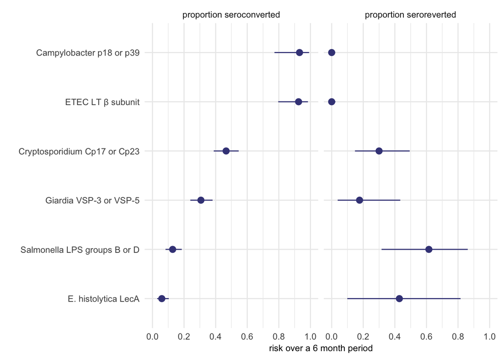

```r
# sort pathogens by rates
ratelabs <- c("E. histolytica LecA",
              "Salmonella LPS groups B or D",
              "Giardia VSP-3 or VSP-5",
              "Cryptosporidium Cp17 or Cp23",
              "ETEC LT β subunit",
              "Campylobacter p18 or p39")


# bind the incidence proportion estimates together for plot aesthetics
est_sero <- est_seroi %>%
  mutate(outcome="proportion seroconverted") %>%
  bind_rows(est_seror) %>%
  mutate(outcome=ifelse(is.na(outcome),"proportion seroreverted",outcome)) %>%
  arrange(antigenf,desc(outcome))

# Drop cholera because of potential cross-reactivity with ETEC heat labile toxin beta subunit
# reverse antigen factor order for coordinate-flipped figure
cuminc_plot_d <- est_sero %>%
  filter(pathogen!="V. cholerae")  %>%
  mutate(antigenf=factor(antigenf,levels=ratelabs))

# bright color-blind palette defined in an earlier code chunk
# pcols <- c(cred,corange,cgreen,cteal,cblue,cmagent,cgrey)
# pcols <- c(corange,cred,cmagent,cchartr,cblue,cteal,cgreen,cgrey)

vircols <- viridis(n=4,alpha=1,begin=0.2,end=0.97)
pcol <- vircols[1]

seroip <- ggplot(data=cuminc_plot_d,
                 aes(x=antigenf,y=mean,
                     # color=antigenf,fill=antigenf
                     )) +
  geom_pointrange(aes(ymin=min95,ymax=max95,group=outcome),color=pcol,size=0.5 ) +
  facet_grid(.~outcome)+

  # facet_wrap(~factor(outcome),nrow=2,ncol=1)+
  labs(x="",y="risk over a 6 month period") +
  scale_y_continuous(breaks=seq(0,1,by=0.2))+
  guides(color = FALSE, fill = FALSE)+
  coord_flip(ylim=c(0,1))+
  theme_minimal() +
  theme(legend.position = "none", legend.title=element_blank(),
        axis.title.y=element_text(color="gray20"),
        axis.title.x=element_text(size=9))

seroip
```

# Figure 5 A, incidence rate figure

**This is Figure 5 A in the manuscript**

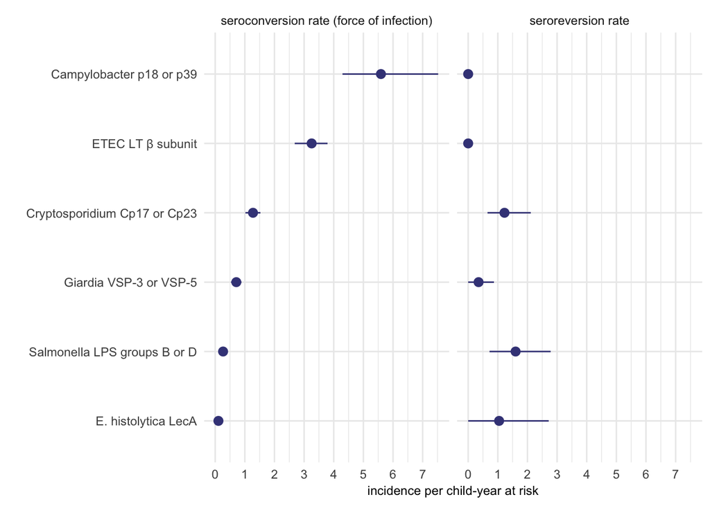

```r
# sort pathogens by rates
ratelabs <- c("E. histolytica LecA",
              "Salmonella LPS groups B or D",
              "Giardia VSP-3 or VSP-5",
              "Cryptosporidium Cp17 or Cp23",
              "ETEC LT β subunit",
              "Campylobacter p18 or p39")

# reshape the incident rate estimates to long
rate_ests_i <- rate_ests %>%
  select(pathogen,antigen,antigenf,n=ni,nt=nit,rate=seroi,rate_lb=seroi_lb,rate_ub=seroi_ub) %>%
  mutate(outcome="seroconversion rate (force of infection)")

rate_ests_r <- rate_ests %>%
  select(pathogen,antigen,antigenf,n=nr,nt=nrt,rate=seror,rate_lb=seror_lb,rate_ub=seror_ub) %>%
  mutate(outcome="seroreversion rate")
rate_ests_long <- bind_rows(rate_ests_i,rate_ests_r) %>%
  arrange(antigenf,desc(outcome))

# Drop cholera because of potential cross-reactivity with ETEC heat labile toxin beta subunit
# make a custom antigen order to sort by rates
rate_plot_d <- rate_ests_long %>%
  filter(pathogen!="V. cholerae") %>%
  mutate(antigenf=factor(antigenf,levels=ratelabs))


# bright color-blind palette defined in an earlier code chunk
# pcols <- c(cred,corange,cgreen,cteal,cblue,cmagent,cgrey)
# pcols <- c(corange,cred,cmagent,cchartr,cblue,cteal,cgreen,cgrey)

vircols <- viridis(n=4,alpha=1,begin=0.2,end=0.97)
pcol <- vircols[1]

rateplot <- ggplot(data=rate_plot_d,
                 aes(x=antigenf,y=rate)) +
  geom_pointrange(aes(ymin=rate_lb,ymax=rate_ub,group=outcome),bg="white",color=pcol,size=0.5 ) +
  #position=position_nudge(x=rep(c(-0.2,0.2),6)
  facet_grid(.~outcome)+
  labs(x="",y="incidence per child-year at risk") +
  scale_y_continuous(breaks=0:7)+
  scale_shape_manual(values=c(19,22)) +
  # scale_fill_manual(values=pcols) +
  # scale_color_manual(values=pcols) +
  guides(color = FALSE, fill = FALSE)+
  # coord_cartesian(ylim=c(0,6))+
  coord_flip() +
  theme_minimal() +
  theme(legend.position = c(0.8,0.9), legend.title=element_blank(),
        axis.title.y=element_text(color="gray20"),
        axis.title.x=element_text(size=9)
        )

rateplot
```

```r
# save pdf and a TIFF version
ggsave(file=here("figs","Fig5a-asembo-seroincidence.pdf"),plot=rateplot,device=cairo_pdf,height=2.4,width=8)
ggsave(file=here("figs","Fig5a-asembo-seroincidence.TIFF"),plot=rateplot,device="tiff",height=2.4,width=8)
```

# Compare seroconversion rates with seroprevalence

For pathogens without seroreversion, age-dependent seroprevalence is a measure of the cumulative distribution of exposure. In turn, this is a measure of the cumulative incidence of seroconversion. Since the seroreversion rate approahed zero for many pathogens studied, we would hypothesize there would be a strong relationship between seroprevalence and the average seroconversion rate over the period. Examine this relationship for each pathogen. Store results of this comparison for plotting in the separate Figure 7 notebook that also includes estimates from the Haiti cohort.

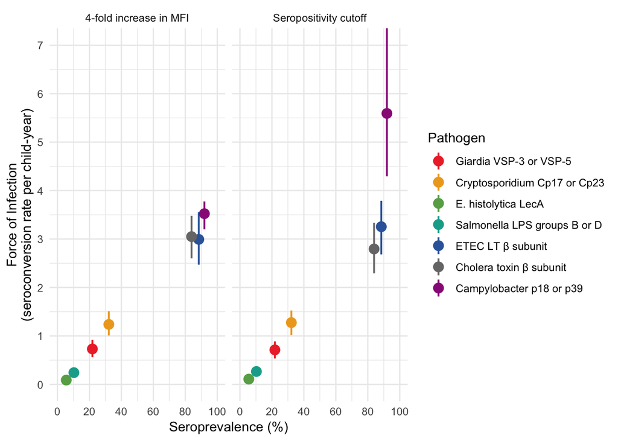

```r
serop <- dlp2 %>%
  group_by(antigenf) %>%
  summarize(seroprev=mean(seropos))

d_seropi <- left_join(rate_ests,serop,by="antigenf") %>%
  mutate(method="Seropositivity cutoff")
d_serop4fold <- left_join(rate_ests_4fold,serop,by="antigenf")  %>%
  mutate(method="4-fold increase in MFI")

d_serop <- bind_rows(d_seropi,d_serop4fold) %>%
  mutate(method=factor(method))


pcols <- c(cred,corange,cgreen,cteal,cblue,cgrey,cmagent)

pserop <- ggplot(data=d_serop,aes(x=seroprev,y=seroi,color=antigenf)) +
  geom_pointrange(aes(,ymin=seroi_lb,ymax=seroi_ub),size=0.7) +
  # geom_text(aes(label=antigenf),nudge_x = d_serop$nudge,hjust=d_serop$just,size=2)+
  facet_grid(.~method)+
  scale_x_continuous(breaks=seq(0,1,by=0.2),labels=seq(0,100,by=20))+
  scale_y_continuous(breaks=0:7)+
  scale_color_manual(values=pcols,guide=guide_legend(title="Pathogen")) +
  coord_cartesian(xlim=c(0,1),ylim=c(0,7))+
  labs(x="Seroprevalence (%)",y="Force of Infection\n(seroconversion rate per child-year)")+
  theme_minimal()
  # theme(legend.position="none")

pserop
```

# Save incidence estimates

```r
saveRDS(rate_ests_long,file=here("output","asembo-enteric-ab-ests-incidencerates.rds"))
saveRDS(est_seroi,file=here("output","asembo-enteric-ab-ests-seroconversion.rds"))
saveRDS(est_seror,file=here("output","asembo-enteric-ab-ests-seroreversion.rds"))
saveRDS(d_serop,file=here("output","asembo-enteric-ab-ests-seroprev-vs-rates.rds"))
```